# Classification

Arie Wahyu Wijayanto - Salwa Rizqina Putri

10/12/2022

# *Methodology*

## Cross-Industry Standard Process for Data Mining (CRISP-DM)

Banyak hasil penelitian yang mengungkapkan bahwa CRISP-DM adalah datamining model yang masih digunakan secara luas di kalangan industry, sebahagian dikarenakan keunggulannya dalam menyelesaikan banyak persoalan dalam proyek proyek data mining.

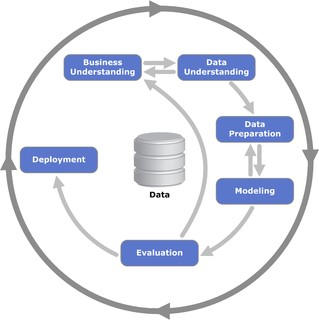

Alur CRISP-DM Data Mining

1. Business Understanding
- Memahami proses data secara komprehensif

Ini adalah tahap pertama dalam CRISP-DM dan termasuk bagian yang cukup vital. Pada tahap ini membutuhkan pengetahuan dari objek bisnis, bagaimana membangun atau mendapatkan data, dan bagaimana untuk mencocokan tujuan pemodelan untuk tujuan bisnis sehingga model terbaik dapat dibangun. Kegiatan yang dilakukan antara lain: menentukan tujuan dan persyaratan dengan jelas secara keseluruhan, menerjemahkan tujuan tersebut serta menentukan pembatasan dalam perumusan masalah data mining, dan selanjutnya mempersiapkan strategi awal untuk mencapai tujuan tersebut.

2. Data Understanding
- Mendapatkan pemahaman awal mengenai data yang dibutuhkan untuk memecahkan permasalahan bisnis yang diberikan

Secara garis besar untuk memeriksa data, sehingga dapat mengidentifikasi masalah dalam data. Tahap ini memberikan fondasi analitik untuk sebuah penelitian dengan membuat ringkasaan (summary) dan mengidentifikasi potensi masalah dalam data. Tahap ini juga harus dilakukan secara cermat dan tidak terburu-buru, seperti pada visualisasi data, yang terkadang insight-nya sangat sulit didapat dika dihubungkan dengan summary data nya. Jika ada masalah pada tahap ini yang belum terjawab, maka akan menggangu pada tahap modeling.

Ringkasan atau summary dari data dapat berguna untuk mengkonfirmasi apakah data terdistribusi seperti yang diharapkan, atau mengungkapkan penyimpangan tak terduga yang perlu ditangani pada tahap selanjutnya, yaitu Data Preperation.

Masalah dalam data biasanya seperti nilai-nilai yang hilang, outlier, berdistribusi spike, berdistribusi bimodal harus diidentifikasi dan diukur sehingga dapat diperbaiki dalam Data Preperation.

3. Data Preparation
- Proses pengumpulan, penggabungan, penataan, dan pengorganisasian data

Secara garis besar untuk memperbaiki masalah dalam data, kemudian membuat variabel derived. Tahap ini jelas membutuhkan pemikiran yang cukup matang dan usaha yang cukup tinggi untuk memastikan data tepat untuk algoritma yang digunakan.

Bukan berarti saat Data Preperation pertama kali dimana masalah-masalah pada data sudah diselesaikan, data sudah dapat digunakan hingga tahap terakhir. Tahap ini merupakan tahap yang sering ditinjau kembali saat menemukan masalah pada saat pembangunan model. Sehingga dilakukan iterasi sampai menemukan hal yang cocok dengan data.

Tahap sampling dapat dilakukan disini dan data secara umum dibagi menjadi dua, data training dan data testing.

Kegiatan yang dilakukan antara lain: memilih kasus dan parameter yang akan dianalisis (Select Data), melakukan transformasi terhadap parameter tertentu (Transformation), dan melakukan pembersihan data agar data siap untuk tahap modeling (Cleaning).

4. Modelling
- Membuat model prediktif atau deskriptif

Secara garis besar untuk membuat model prediktif atau deskriptif. Pada tahap ini dilakukan metode statistika dan Machine Learning untuk penentuan terhadap teknik data mining, alat bantu data mining, dan algoritma data mining yang akan diterapkan. Lalu selanjutnya adalah melakukan penerapan teknik dan algoritma data mining tersebut kepada data dengan bantuan alat bantu. Jika diperlukan penyesuaian data terhadap teknik data mining tertentu, dapat kembali ke tahap data preparation.

Beberapa modeling yang biasa dilakukan adalah classification, scoring, ranking, clustering, finding relation, dan characterization.

5. Evaluation
- Melakukan interpretasi terhadap hasil dari data mining

Melakukan interpretasi terhadap hasil dari data mining yang dihasilkan dalam proses pemodelan pada tahap sebelumnya. Evaluasi dilakukan terhadap model yang diterapkan pada tahap sebelumnya dengan tujuan agar model yang ditentukan dapat sesuai dengan tujuan yang ingin dicapai dalam tahap pertama.

6. Deployment
- Rencana penerapan atau penggunaan model

Tahap deployment atau rencana penggunaan model adalah tahap yang paling dihargai dari proses CRISP-DM. Perencanaan untuk Deployment dimulai selama Business Understanding dan harus menggabungkan tidak hanya bagaimana untuk menghasilkan nilai model, tetapi juga bagaimana mengkonversi skor keputusan, dan bagaimana untuk menggabungkan keputusan dalam sistem operasional.

# 1. Business Understanding

Memahami proses data secara komprehensif

[figure not shown]

Banyak orang berjuang untuk mendapatkan pinjaman karena sejarah kredit yang tidak mencukupi atau tidak ada. Dan, sayangnya, populasi ini sering dimanfaatkan oleh pemberi pinjaman yang tidak dapat dipercaya.

Home Credit berupaya untuk memperluas inklusi keuangan bagi populasi unbanked dengan memberikan pengalaman pinjaman yang positif dan aman. Untuk memastikan populasi yang kurang terlayani ini memiliki pengalaman pinjaman yang positif, Home Credit menggunakan berbagai data alternatif–termasuk telekomunikasi dan informasi transaksi–untuk memprediksi kemampuan pembayaran klien mereka.

Sementara Home Credit saat ini menggunakan berbagai metode statistik dan pembelajaran mesin untuk membuat prediksi ini, mereka menantang kami untuk membantu mereka membuka potensi penuh dari data mereka. Melakukannya akan memastikan bahwa **klien yang mampu membayar tidak ditolak dan pinjaman diberikan dengan pokok, jatuh tempo, dan kalender pembayaran yang akan memberdayakan klien mereka untuk menjadi sukses.**

Company wants to automate the loan eligibility process (real time) based on customer detail provided while filling online application form. These details are Gender, Marital Status, Education, Number of Dependents, Income, Loan Amount, Credit History and others. To automate this process, they have given a problem to identify the customers’ segments, those are eligible for loan amount so that they can specifically Loan_Status these customers. Here they have provided a partial data set.

Perusahaan ingin mengotomatisasi proses kelayakan pinjaman (real time) berdasarkan detail pelanggan yang diberikan saat mengisi formulir aplikasi online. Rincian ini adalah Jenis Kelamin, Status Perkawinan, Pendidikan, Jumlah Tanggungan, Pendapatan, Jumlah Pinjaman, Riwayat Kredit dan lain-lain. Untuk mengotomatisasi proses ini, mereka telah memberikan masalah untuk mengidentifikasi segmen pelanggan, yang memenuhi syarat untuk jumlah pinjaman sehingga mereka dapat secara khusus Loan_Status pelanggan tersebut. Di sini mereka telah menyediakan kumpulan data parsial.

# 2. Data Understanding

Langkah selanjutnya adalah melihat data yang sedang kita kerjakan. Secara realistis, sebagian besar data yang akan kita dapatkan, bahkan dari pemerintah, dapat memiliki kesalahan, dan penting untuk mengidentifikasi kesalahan ini sebelum menghabiskan waktu untuk menganalisis data. Biasanya, kita harus menjawab pertanyaan-pertanyaan berikut:

o Do we find something wrong in the data?

o Are there ambiguous variables in the dataset?

o Are there variables that should be fixed or removed?

## Load Data and Library

```r
library(tidyverse)
```

```
## ✖ purrr::%||%()   masks base::%||%()
```

```r
library(ggplot2)
library(corrplot)
library(corrgram)
library(ROCR)
library(psych)
library(reshape2)
library(VIM)
library(randomForest)
library(mlbench)
library(caret)
library(e1071)
library(AppliedPredictiveModeling)
library(imbalance)
library(dplyr)
library(naivebayes)
library(rpart)
library(RSNNS)
library(LogicReg)
library(kernlab)
library(rpart.plot)
library(openxlsx)
library(skimr)
library(ada)
raw_data = read.csv(file="home_loan.csv", na.strings=c("", "NA"), header=TRUE)
head(raw_data)
```

```
##    Loan_ID Gender Married Dependents    Education Self_Employed ApplicantIncome
## 1 LP001002   Male      No          0     Graduate            No            5849
## 2 LP001003   Male     Yes          1     Graduate            No            4583
## 3 LP001005   Male     Yes          0     Graduate           Yes            3000
## 4 LP001006   Male     Yes          0 Not Graduate            No            2583
## 5 LP001008   Male      No          0     Graduate            No            6000
## 6 LP001011   Male     Yes          2     Graduate           Yes            5417
##   CoapplicantIncome LoanAmount Loan_Amount_Term Credit_History Property_Area
## 1                 0         NA              360              1         Urban
## 2              1508        128              360              1         Rural
## 3                 0         66              360              1         Urban
## 4              2358        120              360              1         Urban
## 5                 0        141              360              1         Urban
## 6              4196        267              360              1         Urban
##   Loan_Status
## 1           Y
## 2           N
## 3           Y
## 4           Y
## 5           Y
## 6           Y
```

**Penggantian Nilai Aneh**

```r
library(plyr)
raw_data$Dependents <- revalue(raw_data$Dependents, c("3+"="3"))
```

**Simpan dataset ke dalam format DataFrame**

Dengan format DataFrame, kita dapat dengan mudah melakukan berbagai perintah dan modifikasi pada data untuk analisis lebih lanjut. Kita dapat menampilkan informasi tipe data dan jumlah baris non-null dari setiap atribut/variabel.

```r
mydata<-data.frame(raw_data[,-1])
str(mydata)
```

```
## 'data.frame':    614 obs. of  12 variables:
##  $ Gender           : chr  "Male" "Male" "Male" "Male" ...
##  $ Married          : chr  "No" "Yes" "Yes" "Yes" ...
##  $ Dependents       : chr  "0" "1" "0" "0" ...
##  $ Education        : chr  "Graduate" "Graduate" "Graduate" "Not Graduate" ...
##  $ Self_Employed    : chr  "No" "No" "Yes" "No" ...
##  $ ApplicantIncome  : int  5849 4583 3000 2583 6000 5417 2333 3036 4006 12841 ...
##  $ CoapplicantIncome: num  0 1508 0 2358 0 ...
##  $ LoanAmount       : int  NA 128 66 120 141 267 95 158 168 349 ...
##  $ Loan_Amount_Term : int  360 360 360 360 360 360 360 360 360 360 ...
##  $ Credit_History   : int  1 1 1 1 1 1 1 0 1 1 ...
##  $ Property_Area    : chr  "Urban" "Rural" "Urban" "Urban" ...
##  $ Loan_Status      : chr  "Y" "N" "Y" "Y" ...
```

**Ubah semua kolom/atribut yang bertipe karakter menjadi faktor**

```r
str(mydata)
```

```
## 'data.frame':    614 obs. of  12 variables:
##  $ Gender           : chr  "Male" "Male" "Male" "Male" ...
##  $ Married          : chr  "No" "Yes" "Yes" "Yes" ...
##  $ Dependents       : chr  "0" "1" "0" "0" ...
##  $ Education        : chr  "Graduate" "Graduate" "Graduate" "Not Graduate" ...
##  $ Self_Employed    : chr  "No" "No" "Yes" "No" ...
##  $ ApplicantIncome  : int  5849 4583 3000 2583 6000 5417 2333 3036 4006 12841 ...
##  $ CoapplicantIncome: num  0 1508 0 2358 0 ...
##  $ LoanAmount       : int  NA 128 66 120 141 267 95 158 168 349 ...
##  $ Loan_Amount_Term : int  360 360 360 360 360 360 360 360 360 360 ...
##  $ Credit_History   : int  1 1 1 1 1 1 1 0 1 1 ...
##  $ Property_Area    : chr  "Urban" "Rural" "Urban" "Urban" ...
##  $ Loan_Status      : chr  "Y" "N" "Y" "Y" ...
```

```r
mydata <- as.data.frame(unclass(mydata), stringsAsFactors = TRUE)

mydata[, c('Gender','Married','Dependents','Education','Self_Employed','Property_Area','Loan_Status')] <- sapply(mydata[, c('Gender','Married','Dependents','Education','Self_Employed','Property_Area','Loan_Status')], unclass)

head(mydata)
```

```
##   Gender Married Dependents Education Self_Employed ApplicantIncome
## 1      2       1          1         1             1            5849
## 2      2       2          2         1             1            4583
## 3      2       2          1         1             2            3000
## 4      2       2          1         2             1            2583
## 5      2       1          1         1             1            6000
## 6      2       2          3         1             2            5417
##   CoapplicantIncome LoanAmount Loan_Amount_Term Credit_History Property_Area
## 1                 0         NA              360              1             3
## 2              1508        128              360              1             1
## 3                 0         66              360              1             3
## 4              2358        120              360              1             3
## 5                 0        141              360              1             3
## 6              4196        267              360              1             3
##   Loan_Status
## 1           2
## 2           1
## 3           2
## 4           2
## 5           2
## 6           2
```

```r
skimmed <- skim_to_wide(mydata)
skimmed
```

Data summary

| Name | Piped data |
| --- | --- |
| Number of rows | 614 |
| Number of columns | 12 |
| _______________________ |  |
| Column type frequency: |  |
| numeric | 12 |
| ________________________ |  |
| Group variables | None |

**Variable type: numeric**

| skim_variable | n_missing | complete_rate | mean | sd | p0 | p25 | p50 | p75 | p100 | hist |
| --- | --- | --- | --- | --- | --- | --- | --- | --- | --- | --- |
| Gender | 13 | 0.98 | 1.81 | 0.39 | 1 | 2.0 | 2.0 | 2.00 | 2 | ▂▁▁▁▇ |
| Married | 3 | 1.00 | 1.65 | 0.48 | 1 | 1.0 | 2.0 | 2.00 | 2 | ▅▁▁▁▇ |
| Dependents | 15 | 0.98 | 1.76 | 1.02 | 1 | 1.0 | 1.0 | 3.00 | 4 | ▇▂▁▂▁ |
| Education | 0 | 1.00 | 1.22 | 0.41 | 1 | 1.0 | 1.0 | 1.00 | 2 | ▇▁▁▁▂ |
| Self_Employed | 32 | 0.95 | 1.14 | 0.35 | 1 | 1.0 | 1.0 | 1.00 | 2 | ▇▁▁▁▁ |
| ApplicantIncome | 0 | 1.00 | 5403.46 | 6109.04 | 150 | 2877.5 | 3812.5 | 5795.00 | 81000 | ▇▁▁▁▁ |
| CoapplicantIncome | 0 | 1.00 | 1621.25 | 2926.25 | 0 | 0.0 | 1188.5 | 2297.25 | 41667 | ▇▁▁▁▁ |
| LoanAmount | 22 | 0.96 | 146.41 | 85.59 | 9 | 100.0 | 128.0 | 168.00 | 700 | ▇▃▁▁▁ |
| Loan_Amount_Term | 14 | 0.98 | 342.00 | 65.12 | 12 | 360.0 | 360.0 | 360.00 | 480 | ▁▁▁▇▁ |
| Credit_History | 50 | 0.92 | 0.84 | 0.36 | 0 | 1.0 | 1.0 | 1.00 | 1 | ▂▁▁▁▇ |
| Property_Area | 0 | 1.00 | 2.04 | 0.79 | 1 | 1.0 | 2.0 | 3.00 | 3 | ▆▁▇▁▇ |
| Loan_Status | 0 | 1.00 | 1.69 | 0.46 | 1 | 1.0 | 2.0 | 2.00 | 2 | ▃▁▁▁▇ |

## Statistika Deskriptif

Pada statistika deskriptif disajikan ringkasan data dengan memperhatikan bagaimana pola persebaran data, nilai minimum, maksimum, rata-rata, standar deviasi, dan apakah data hanya berkumpul dalam rentang kuartil tertentu yang nantinya penting bagi kita untuk melakukan langkah *preprocessing* selanjutnya.

```r
skimmed <- skim_to_wide(mydata)
skimmed
```

Data summary

| Name | Piped data |
| --- | --- |
| Number of rows | 614 |
| Number of columns | 12 |
| _______________________ |  |
| Column type frequency: |  |
| numeric | 12 |
| ________________________ |  |
| Group variables | None |

**Variable type: numeric**

| skim_variable | n_missing | complete_rate | mean | sd | p0 | p25 | p50 | p75 | p100 | hist |
| --- | --- | --- | --- | --- | --- | --- | --- | --- | --- | --- |
| Gender | 13 | 0.98 | 1.81 | 0.39 | 1 | 2.0 | 2.0 | 2.00 | 2 | ▂▁▁▁▇ |
| Married | 3 | 1.00 | 1.65 | 0.48 | 1 | 1.0 | 2.0 | 2.00 | 2 | ▅▁▁▁▇ |
| Dependents | 15 | 0.98 | 1.76 | 1.02 | 1 | 1.0 | 1.0 | 3.00 | 4 | ▇▂▁▂▁ |
| Education | 0 | 1.00 | 1.22 | 0.41 | 1 | 1.0 | 1.0 | 1.00 | 2 | ▇▁▁▁▂ |
| Self_Employed | 32 | 0.95 | 1.14 | 0.35 | 1 | 1.0 | 1.0 | 1.00 | 2 | ▇▁▁▁▁ |
| ApplicantIncome | 0 | 1.00 | 5403.46 | 6109.04 | 150 | 2877.5 | 3812.5 | 5795.00 | 81000 | ▇▁▁▁▁ |
| CoapplicantIncome | 0 | 1.00 | 1621.25 | 2926.25 | 0 | 0.0 | 1188.5 | 2297.25 | 41667 | ▇▁▁▁▁ |
| LoanAmount | 22 | 0.96 | 146.41 | 85.59 | 9 | 100.0 | 128.0 | 168.00 | 700 | ▇▃▁▁▁ |
| Loan_Amount_Term | 14 | 0.98 | 342.00 | 65.12 | 12 | 360.0 | 360.0 | 360.00 | 480 | ▁▁▁▇▁ |
| Credit_History | 50 | 0.92 | 0.84 | 0.36 | 0 | 1.0 | 1.0 | 1.00 | 1 | ▂▁▁▁▇ |
| Property_Area | 0 | 1.00 | 2.04 | 0.79 | 1 | 1.0 | 2.0 | 3.00 | 3 | ▆▁▇▁▇ |
| Loan_Status | 0 | 1.00 | 1.69 | 0.46 | 1 | 1.0 | 2.0 | 2.00 | 2 | ▃▁▁▁▇ |

## Visualisasi Data

Visualisasi data adalah proses membuat representasi visual dari data.

Visualisasi data merupakan alat yang ampuh untuk menjelajahi kumpulan data yang besar dan kompleks.

Memvisualisasikan data membantu pengguna untuk memahami pola, tren, hubungan, dan outlier yang tersembunyi di dalam data yang besar dan kompleks.

## Visualisasi Data Numerik

### Applicant Income

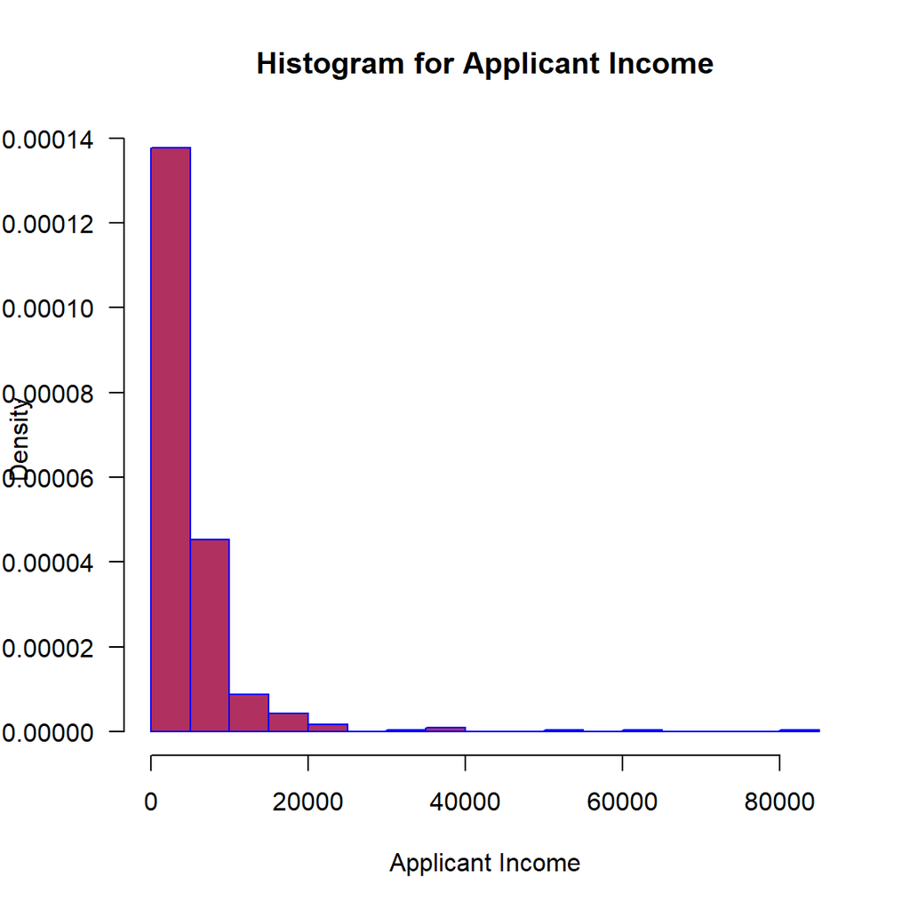

```r
hist(mydata$ApplicantIncome,
     main="Histogram for Applicant Income",
     xlab="Applicant Income",
     border="blue",
     col="maroon",
     las=1,
     breaks=20, prob = TRUE)
```

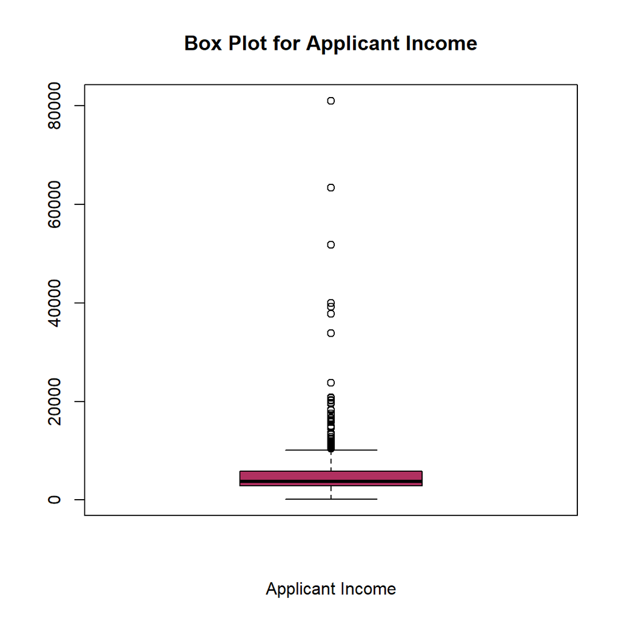

```r
boxplot(mydata$ApplicantIncome, col='maroon',xlab = 'Applicant Income', main = 'Box Plot for Applicant Income')
```

### Coapplicant Income

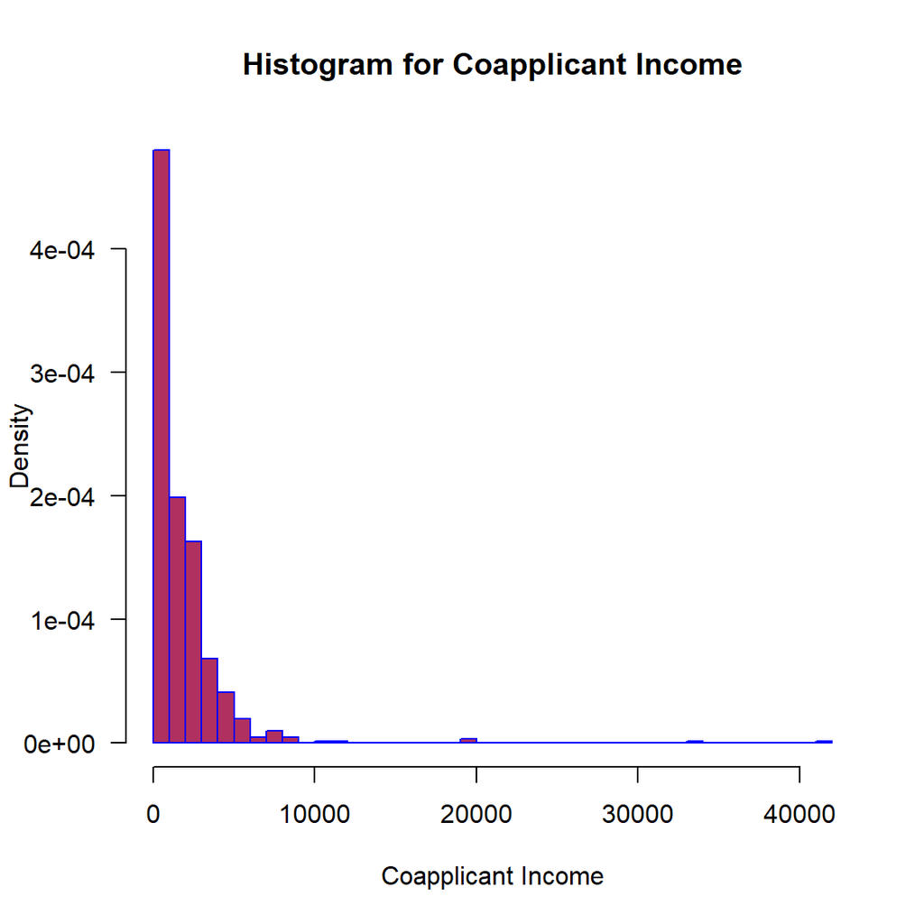

```r
hist(mydata$CoapplicantIncome,
     main="Histogram for Coapplicant Income",
     xlab="Coapplicant Income",
     border="blue",
     col="maroon",
     las=1,
     breaks=50, prob = TRUE)
```

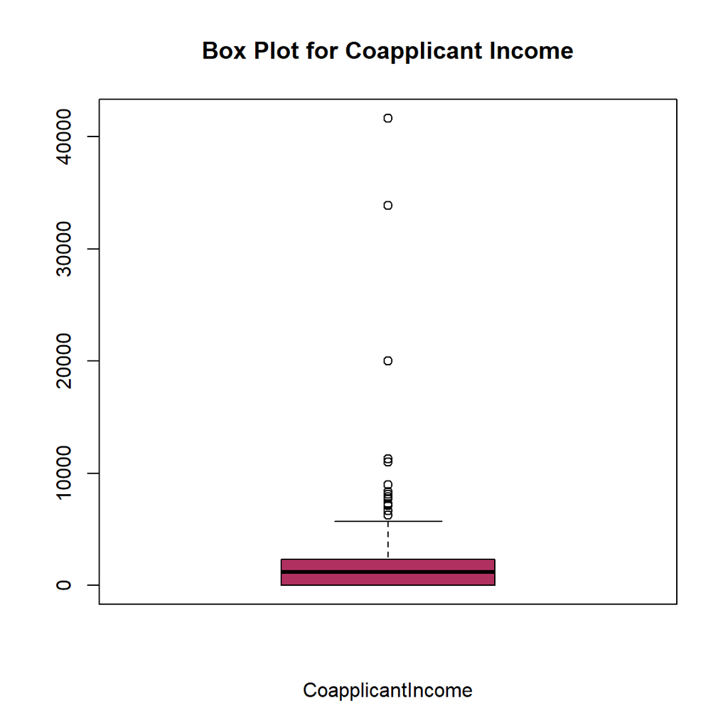

```r
boxplot(mydata$CoapplicantIncome, col='maroon',xlab = 'CoapplicantIncome', main = 'Box Plot for Coapplicant Income')
```

### Loan Amount

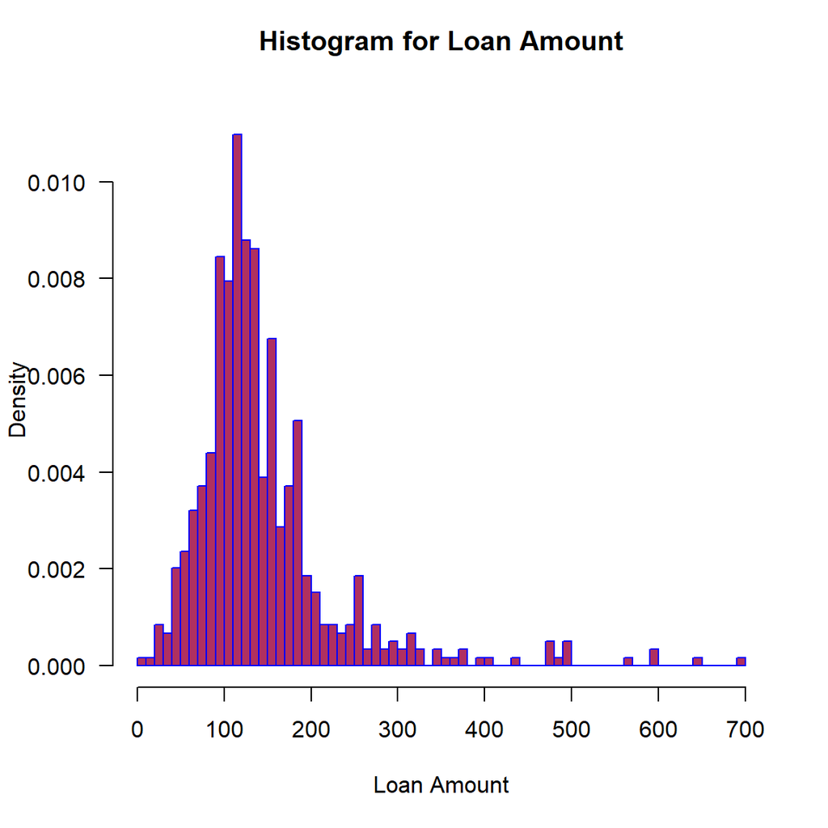

```r
hist(mydata$LoanAmount,
     main="Histogram for Loan Amount
",
     xlab="Loan Amount",
     border="blue",
     col="maroon",
     las=1,
     breaks=50, prob = TRUE)
```

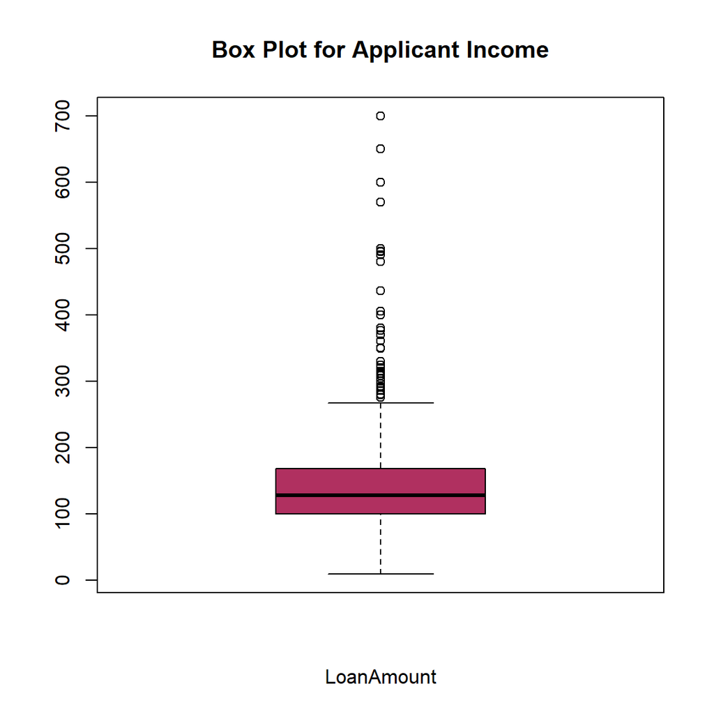

```r
boxplot(mydata$LoanAmount, col='maroon',xlab = 'LoanAmount', main = 'Box Plot for Applicant Income')
```

### Loan_Amount_Term

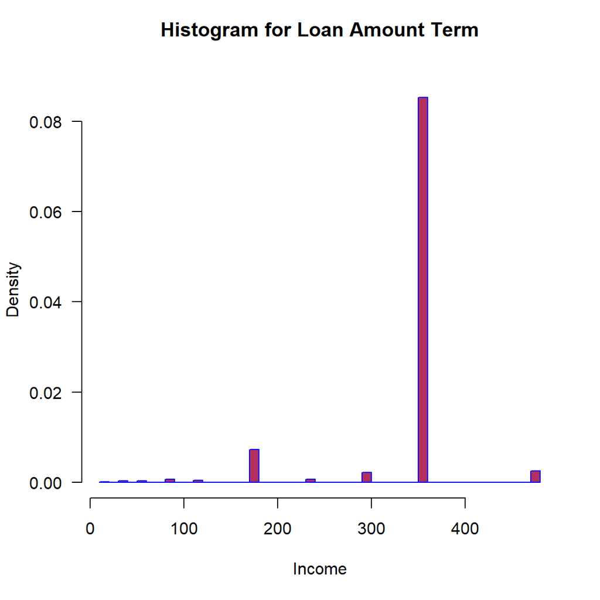

```r
hist(mydata$Loan_Amount_Term,
     main="Histogram for Loan Amount Term
",
     xlab="Income",
     border="blue",
     col="maroon",
     las=1,
     breaks=50, prob = TRUE)
```

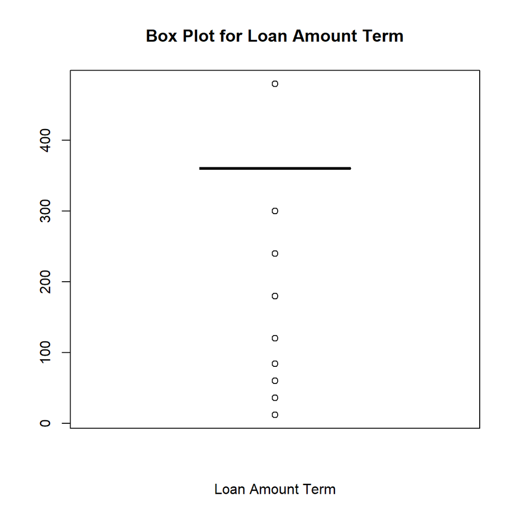

```r
#lines(density(tr$ApplicantIncome), col='black', lwd=3)
boxplot(mydata$Loan_Amount_Term, col='maroon',xlab = 'Loan Amount Term', main = 'Box Plot for Loan Amount Term')
```

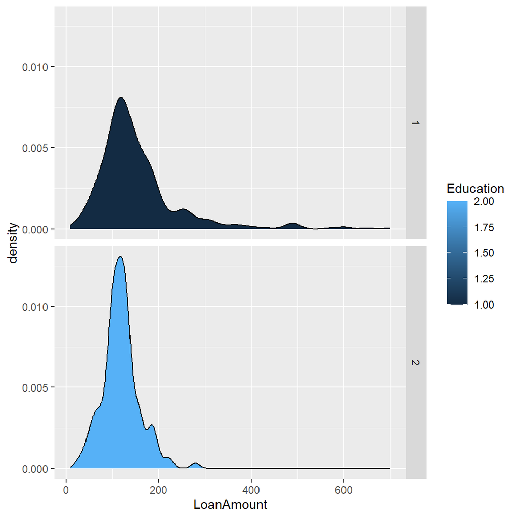

```r
library(ggplot2)
data(tr, package="lattice")
ggplot(data=mydata, aes(x=LoanAmount, fill=Education)) +
  geom_density() +
  facet_grid(Education~.)
```

Dapat terlihat bahwa lulusan memiliki lebih banyak outlier dan distribusi jumlah pinjaman mereka lebih luas.

## Visualisasi Data Kategorik

Sekarang mari kita lihat variabel kategori dalam dataset.

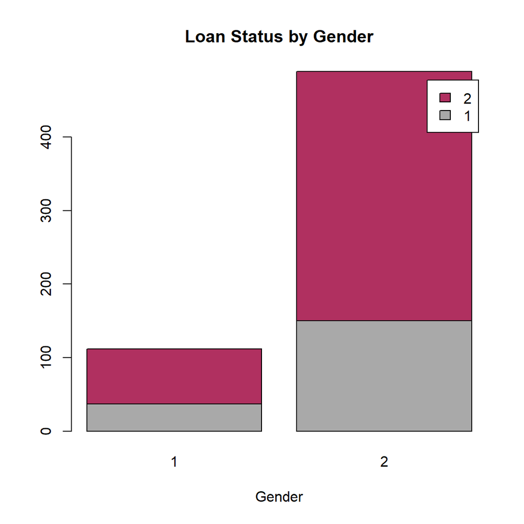

```r
counts <- table(mydata$Loan_Status, mydata$Gender)
barplot(counts, main="Loan Status by Gender",
        xlab="Gender", col=c("darkgrey","maroon"),
        legend = rownames(counts))
```

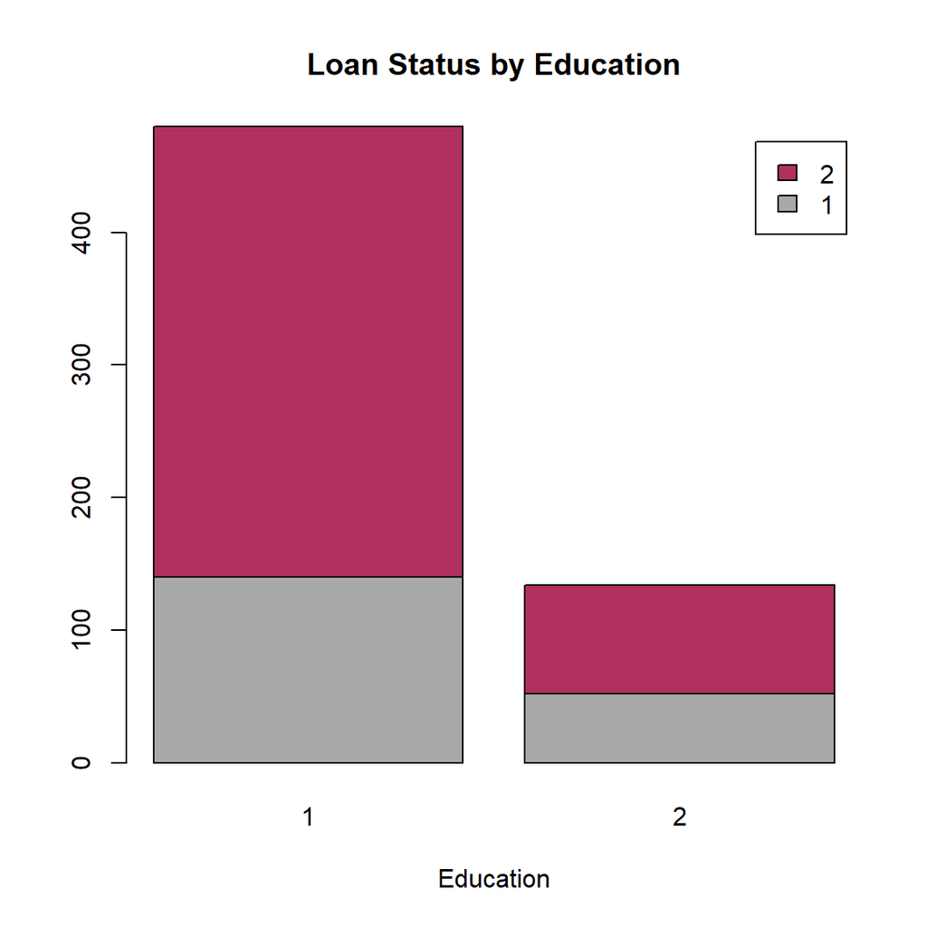

```r
counts2 <- table(mydata$Loan_Status, mydata$Education)
barplot(counts2, main="Loan Status by Education",
        xlab="Education", col=c("darkgrey","maroon"),
        legend = rownames(counts2))
```

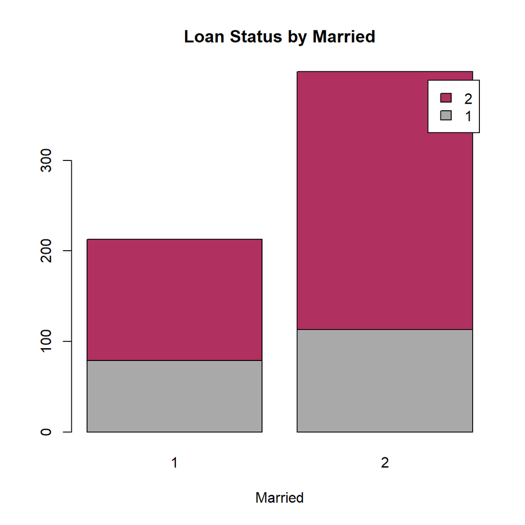

```r
counts3 <- table(mydata$Loan_Status, mydata$Married)
barplot(counts3, main="Loan Status by Married",
        xlab="Married", col=c("darkgrey","maroon"),
        legend = rownames(counts3))
```

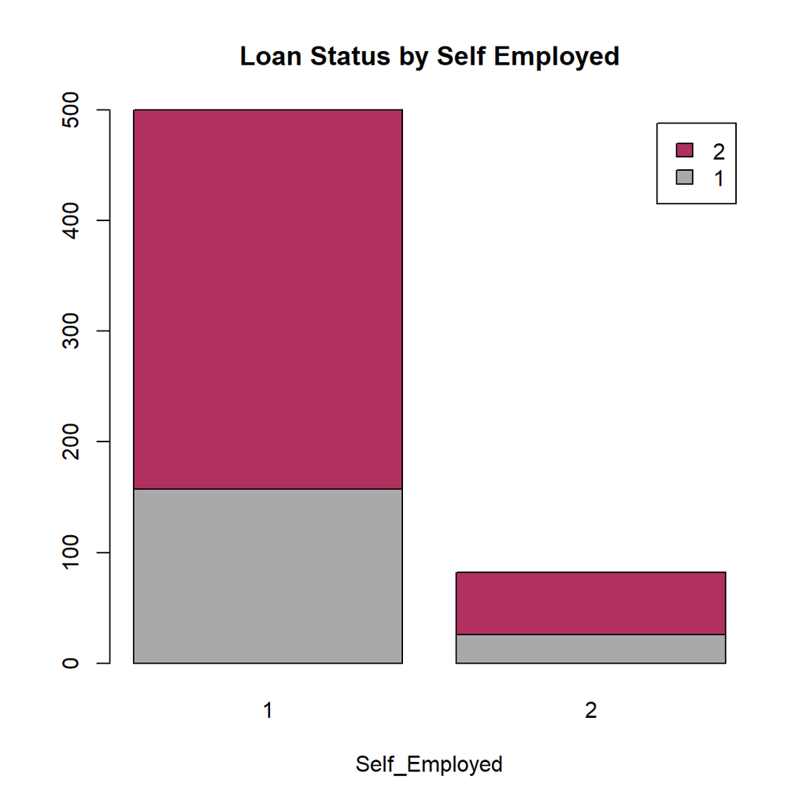

```r
counts4 <- table(mydata$Loan_Status, mydata$Self_Employed)
barplot(counts4, main="Loan Status by Self Employed",
        xlab="Self_Employed", col=c("darkgrey","maroon"),
        legend = rownames(counts4))
```

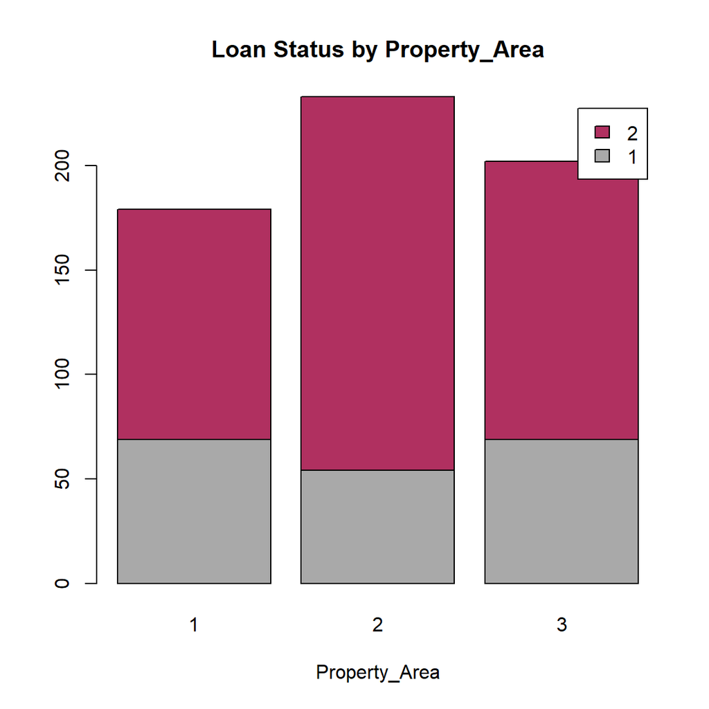

```r
counts5 <- table(mydata$Loan_Status, mydata$Property_Area)
barplot(counts5, main="Loan Status by Property_Area",
        xlab="Property_Area", col=c("darkgrey","maroon"),
        legend = rownames(counts5))
```

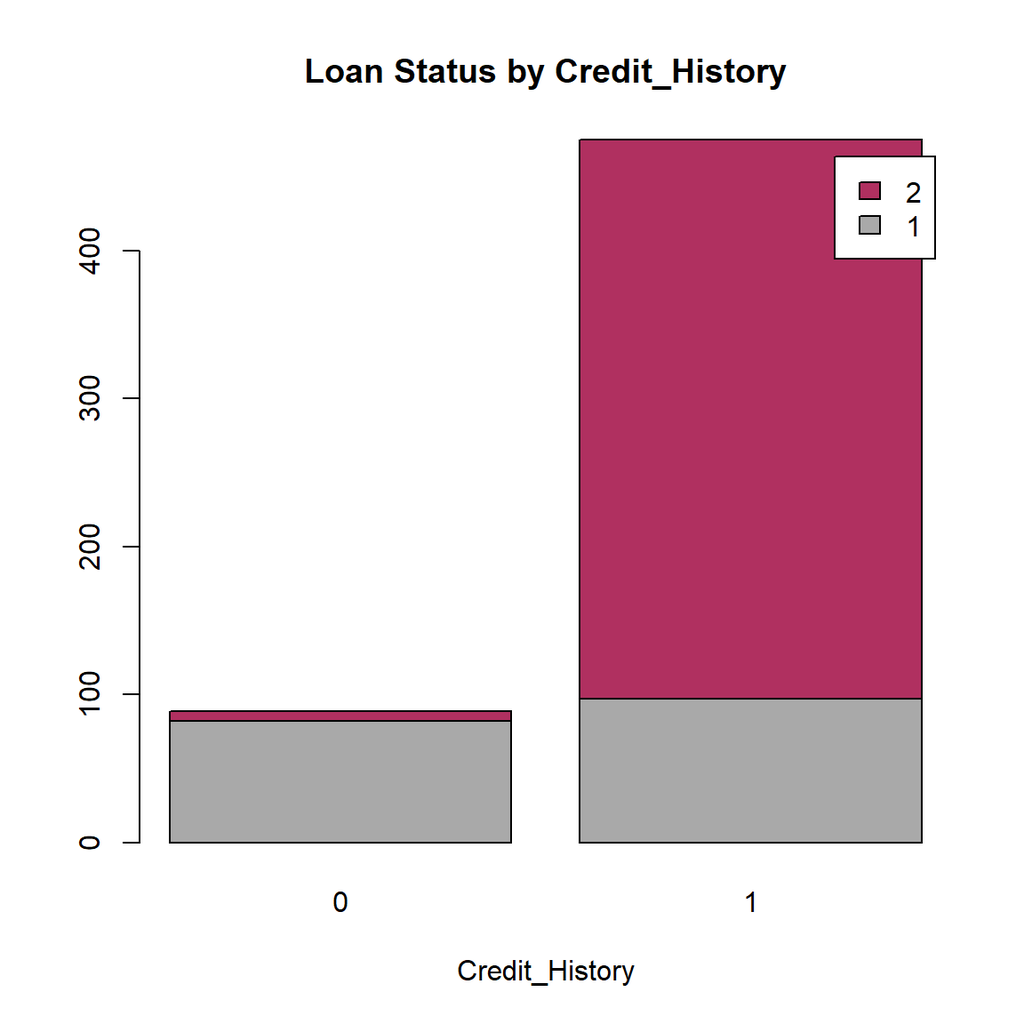

```r
counts6 <- table(mydata$Loan_Status, mydata$Credit_History)
barplot(counts6, main="Loan Status by Credit_History",
        xlab="Credit_History", col=c("darkgrey","maroon"),
        legend = rownames(counts5))
```

## Imbalance Data Chech

Memeriksa apakah data kita *imbalance* atau tidak

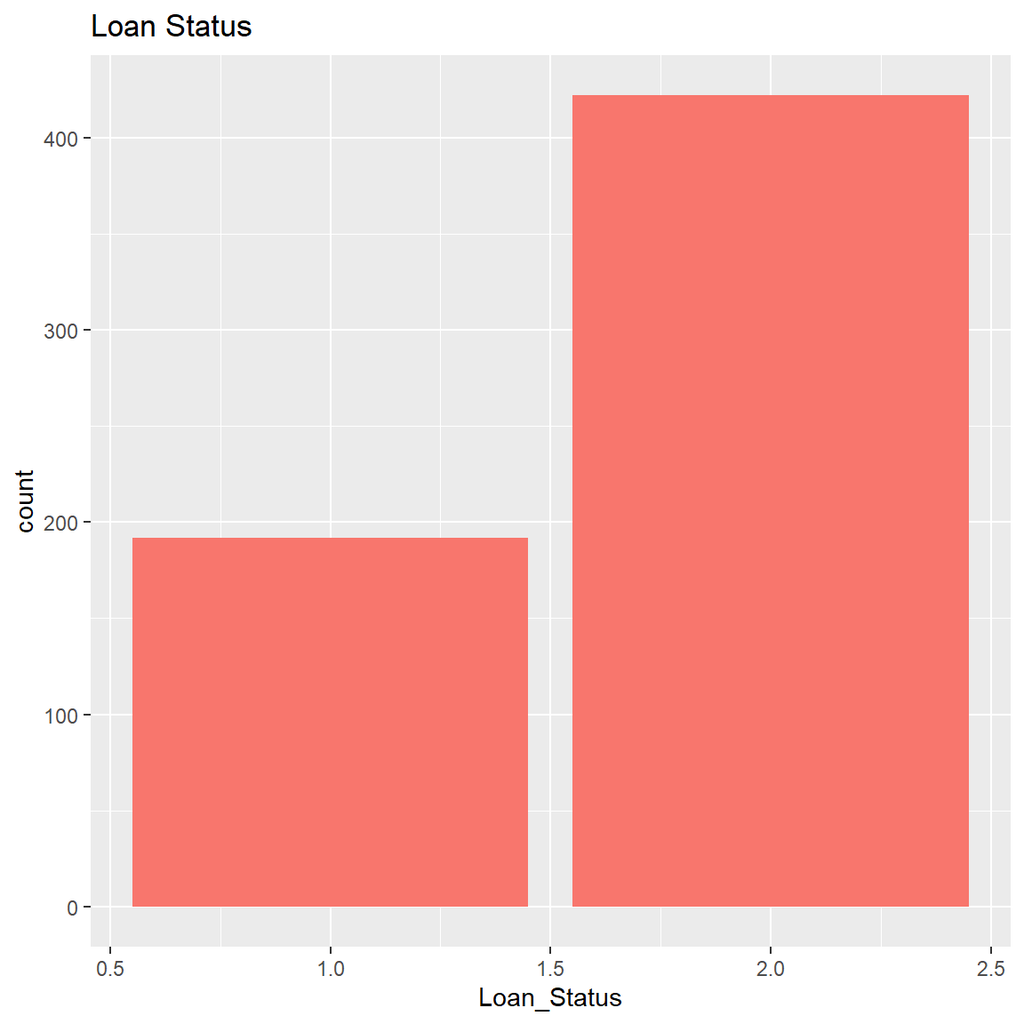

```r
createPlot<-function(loadedData){
ggplot(loadedData, aes(x = Loan_Status)) +
  geom_bar(aes(fill = "yellow")) +
  ggtitle("Loan Status") +
  theme(legend.position="none")
}

createPlot(mydata)
```

## *Imputation Missing Values*

Memeriksa data yang hilang

```r
sapply(mydata,function(x) sum(is.na(x)))
```

```
##            Gender           Married        Dependents         Education
##                13                 3                15                 0
##     Self_Employed   ApplicantIncome CoapplicantIncome        LoanAmount
##                32                 0                 0                22
##  Loan_Amount_Term    Credit_History     Property_Area       Loan_Status
##                14                50                 0                 0
```

```r
mydata$CoapplicantIncome[is.na(mydata$CoapplicantIncome)] <- mean(mydata$CoapplicantIncome, na.rm = TRUE)
```

Imputasi dengan metode KNN

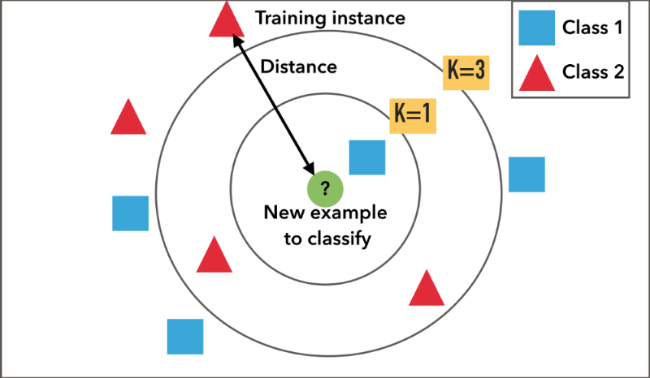

```r
set.seed(125)
mydata
```

[output not shown]

[output cut: 1830 more lines]

```r
thisdata = kNN(mydata, k=5, imp_var = FALSE)
sapply(thisdata,function(x) sum(is.na(x)))
```

```
##            Gender           Married        Dependents         Education
##                 0                 0                 0                 0
##     Self_Employed   ApplicantIncome CoapplicantIncome        LoanAmount
##                 0                 0                 0                 0
##  Loan_Amount_Term    Credit_History     Property_Area       Loan_Status
##                 0                 0                 0                 0
```

## Treat Extreme Values

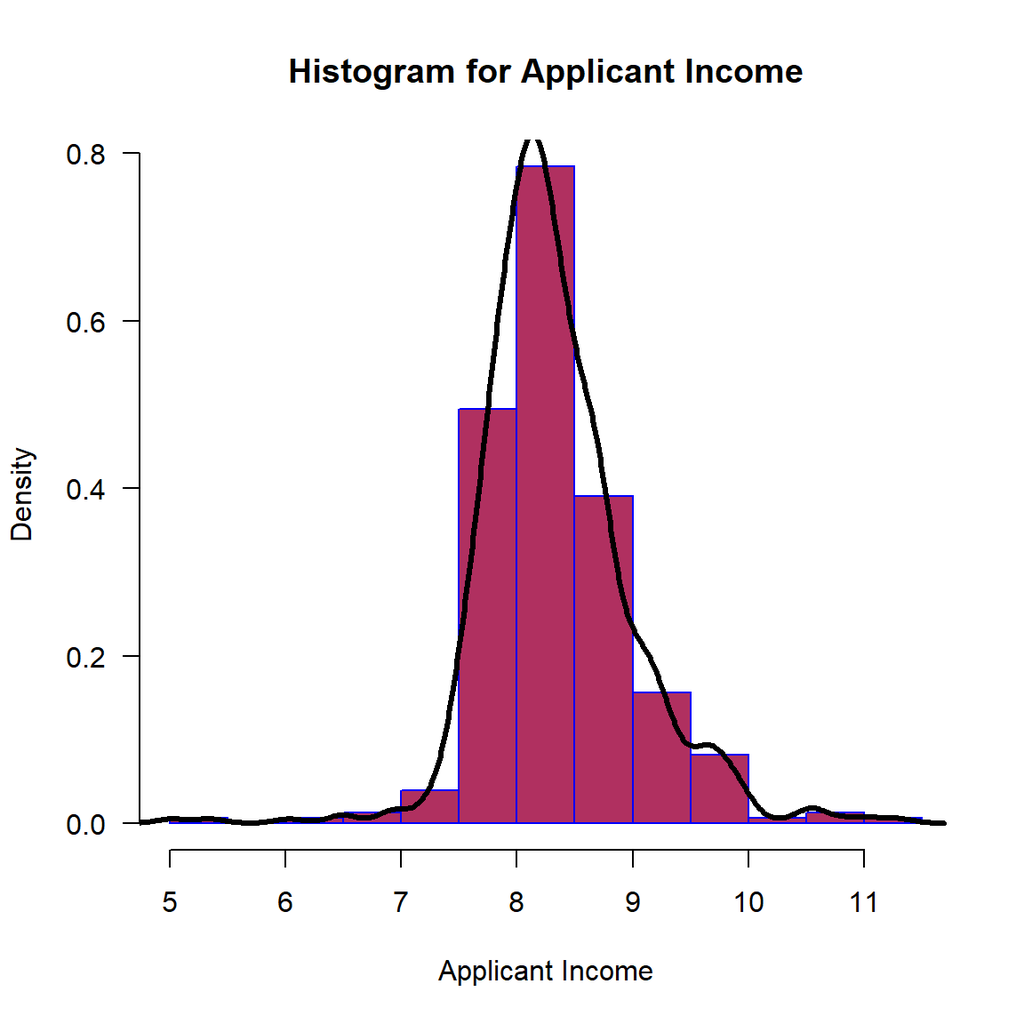

```r
thisdata$ApplicantIncome = log(thisdata$ApplicantIncome)
hist(thisdata$ApplicantIncome,
     main="Histogram for Applicant Income",
     xlab="Applicant Income",
     border="blue",
     col="maroon",
     las=1,
     breaks=20, prob = TRUE)
lines(density(thisdata$ApplicantIncome), col='black', lwd=3)
```

### Coapplicant Income

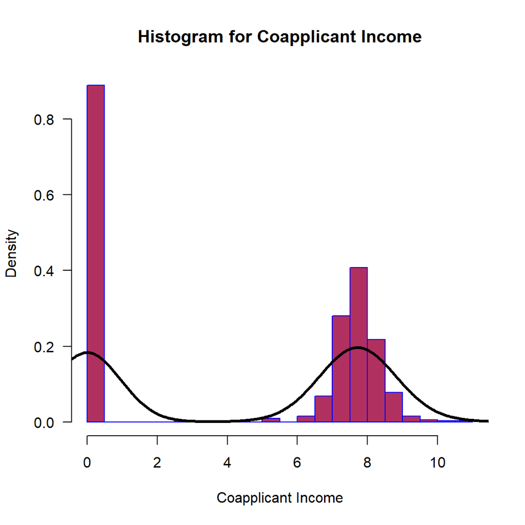

```r
thisdata$CoapplicantIncome <- log(thisdata$CoapplicantIncome+1)
hist(thisdata$CoapplicantIncome,
     main="Histogram for Coapplicant Income",
     xlab="Coapplicant Income",
     border="blue",
     col="maroon",
     las=1,
     breaks=20, prob = TRUE)
lines(density(thisdata$CoapplicantIncome), col='black', lwd=3)
```

### Loan Amount

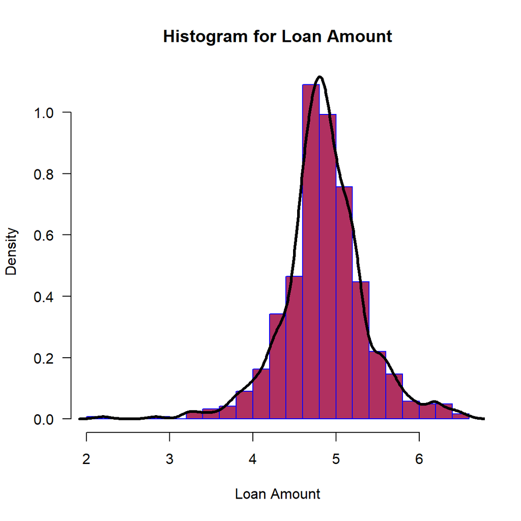

```r
thisdata$LoanAmount <- log(thisdata$LoanAmount)
hist(thisdata$LoanAmount,
     main="Histogram for Loan Amount",
     xlab="Loan Amount",
     border="blue",
     col="maroon",
     las=1,
     breaks=20, prob = TRUE)
lines(density(thisdata$LoanAmount), col='black', lwd=3)
```

### Loan Amount Term

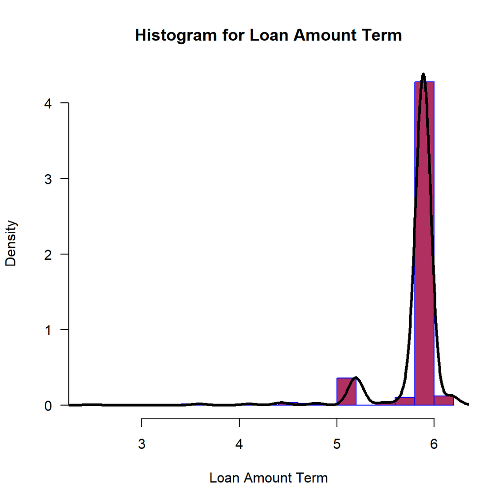

```r
thisdata$Loan_Amount_Term <- log(thisdata$Loan_Amount_Term)
hist(thisdata$Loan_Amount_Term,
     main="Histogram for Loan Amount Term",
     xlab="Loan Amount Term",
     border="blue",
     col="maroon",
     las=1,
     breaks=20, prob = TRUE)
lines(density(thisdata$Loan_Amount_Term), col='black', lwd=3)
```

## Analisis Korelasi

Periksa korelasi antar fitur.

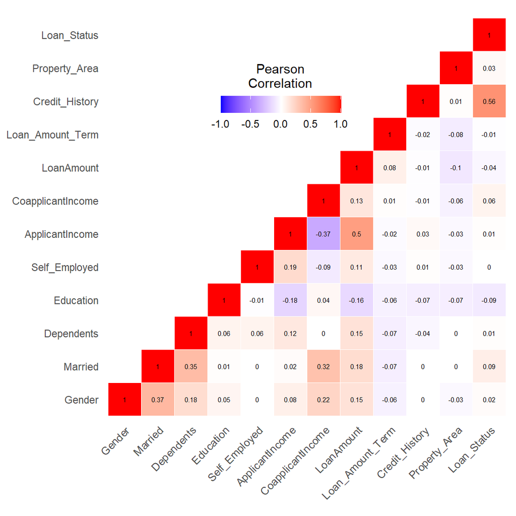

```r
cordata <- data.matrix(thisdata)
cormat <- round(cor(cordata, method = "pearson"),2)
melted_cormat <- melt(cormat)


# Peroleh segitiga bawah dari matriks korelasi
  get_lower_tri<-function(cormat){
    cormat[upper.tri(cormat)] <- NA
    return(cormat)
  }
# Peroleh segitiga atas dari matriks korelasi
  get_upper_tri <- function(cormat){
    cormat[lower.tri(cormat)]<- NA
    return(cormat)
  }

upper_tri <- get_upper_tri(cormat)
# Atur matriks korelasi
melted_cormat <- melt(upper_tri, na.rm = TRUE)
# Buat ggheatmap
ggheatmap <- ggplot(melted_cormat, aes(Var2, Var1, fill = value))+
 geom_tile(color = "white")+
 scale_fill_gradient2(low = "blue", high = "red", mid = "white",
   midpoint = 0, limit = c(-1,1), space = "Lab",
    name="Pearson\nCorrelation") +
  theme_minimal()+ # minimal theme
 theme(axis.text.x = element_text(angle = 45, vjust = 1,
    size = 9, hjust = 1))+
 coord_fixed()

ggheatmap +
geom_text(aes(Var2, Var1, label = value), color = "black", size = 2) +
theme(
  axis.title.x = element_blank(),
  axis.title.y = element_blank(),
  panel.grid.major = element_blank(),
  panel.border = element_blank(),
  panel.background = element_blank(),
  axis.ticks = element_blank(),
  legend.justification = c(1, 0),
  legend.position = c(0.6, 0.7),
  legend.direction = "horizontal")+
  guides(fill = guide_colorbar(barwidth = 7, barheight = 1,
                title.position = "top", title.hjust = 0.5))
```

# 3. Data Preparation

## Cek Imbalance

Imbalance data atau data tidak berimbang merupakan kondisi dimana salah satu atau lebih dari class yang ada dalam suatu himpunan memiliki jumlah yang cukup timpang atau memliki perbedaan yang cukup jauh diantara class yang ada. Contoh nya misalkan pada suatu himpunan data yang terdiri dari dua kelas memiliki perbandingan rasio 1:100 atau 1:1000 dan seterusnya. Kondisi tersebut menyebabkan imbalance data yang dampaknya menyebabkan hasil analisis bias dan tidak optimal.

Distribusi class atau kategori dan rasio imbalance dari data asli

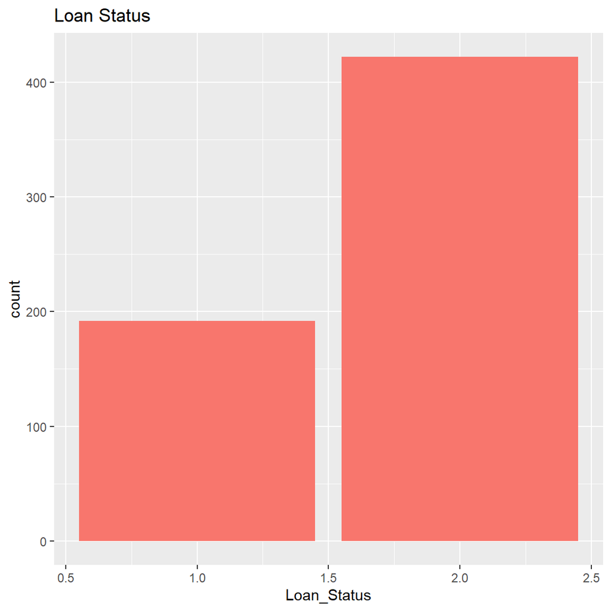

```r
plotImbalance<-function(data){
#  abbrev_x <- c("","No","","Yes","")
  ggplot(data, aes(x = Loan_Status)) +
    geom_bar(aes(fill = "blue")) +
#    scale_x_continuous(breaks = seq(0.5,2.5,by=0.5), labels = abbrev_x) +
    ggtitle("Loan Status") +
    theme(legend.position="none")
}
plotImbalance(thisdata)
```

Masalah dengan melatih model dengan dataset yang tidak seimbang adalah model akan bias terhadap kelas mayoritas saja. Hal ini menyebabkan masalah ketika kita tertarik pada prediksi kelas minoritas (masalah dataset loan status ‘No’ dianggap lebih penting daripada loan status ‘Yes’).

```r
imbalanceRatio(thisdata, classAttr = "Loan_Status")
```

```
## [1] 0.4549763
```

### Resampling

Kita akan membandingkan beberapa algoritma resampling untuk menyeimbangkan distribusi data kita.

### Synthetic Minority Over-sampling Technique (SMOTE)

Metode Synthetic Minority Over-sampling Technique (SMOTE) merupakan metode yang populer diterapkan dalam rangka menangani ketidak seimbangan kelas. Teknik ini mensintesis sampel baru dari kelas minoritas untuk menyeimbangkan dataset dengan cara sampling ulang sampel kelas minoritas.

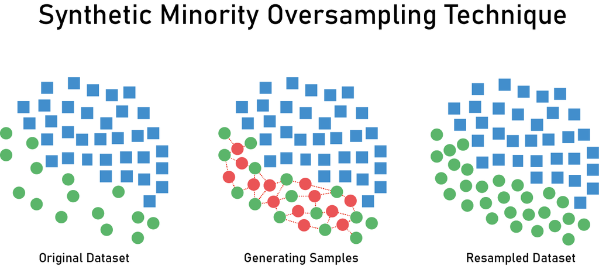

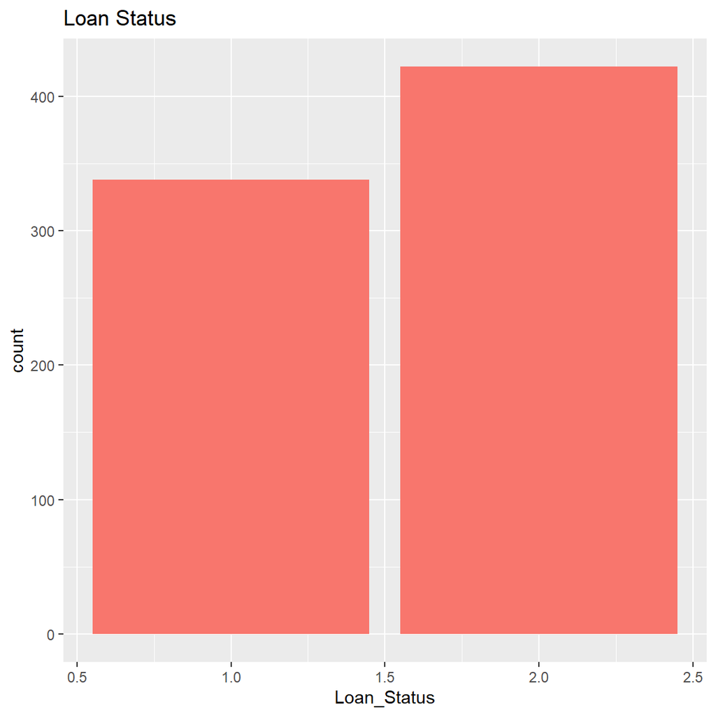

```r
set.seed(345)
dataSMOTE <- oversample(thisdata, ratio = 0.8, method = "SMOTE", classAttr = "Loan_Status")
plotImbalance(dataSMOTE)
```

```r
imbalanceRatio(dataSMOTE, classAttr = "Loan_Status")
```

```
## [1] 0.8009479
```

### Adaptive Synthetic (ADASYN)

ADASYN (Adaptive Synthetic) adalah algoritme yang menghasilkan data sintetis, dan keuntungan terbesarnya adalah tidak menyalin data minoritas yang sama, dan menghasilkan lebih banyak data untuk contoh yang “lebih sulit dipelajari”.

Lebih lanjut: https://medium.com/@ruinian/an-introduction-to-adasyn-with-code-1383a5ece7aa

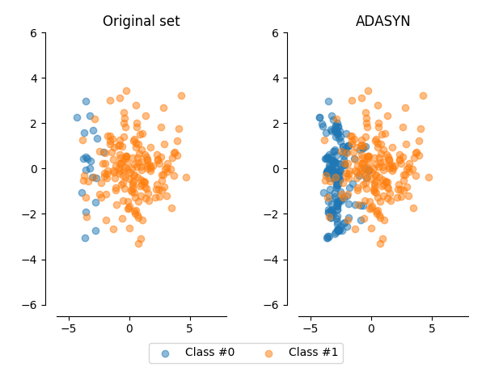

ADASYN (image source: https://medium.com/@ruinian/an-introduction-to-adasyn-with-code-1383a5ece7aa)

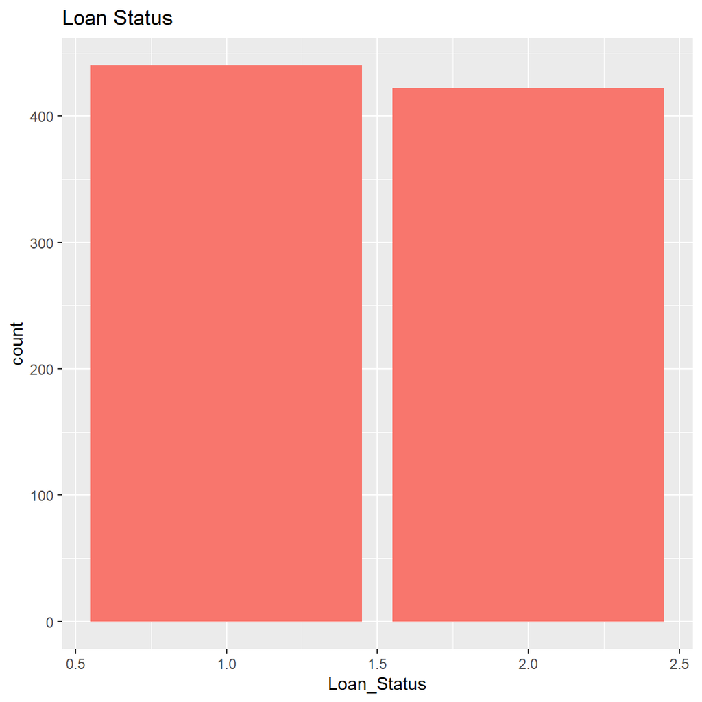

```r
set.seed(123)
dataADASYN <- oversample(thisdata, method = "ADASYN", classAttr = "Loan_Status")
plotImbalance(dataADASYN)
```

```r
imbalanceRatio(dataADASYN, classAttr = "Loan_Status")
```

```
## [1] 0.9590909
```

### Majority-Weighted Minority Over-sampling Technique (MWMOTE)

MWMOTE merupakan metode yang men-generate data sintetis berdasarkan anggota cluster kelas minoritas yang berdekatan dengan kelas mayoritas. Metode ini dapat menangani overfitting dengan men-generate data sintetis secara baik dan mampu menghindari data sintetis yang dihasilkan menjadi data noise.

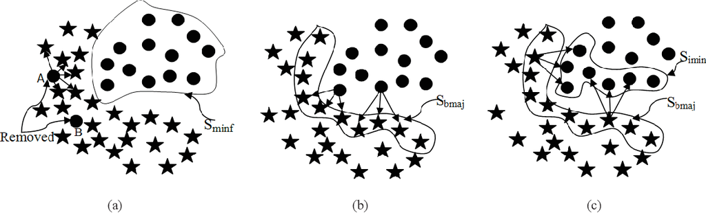

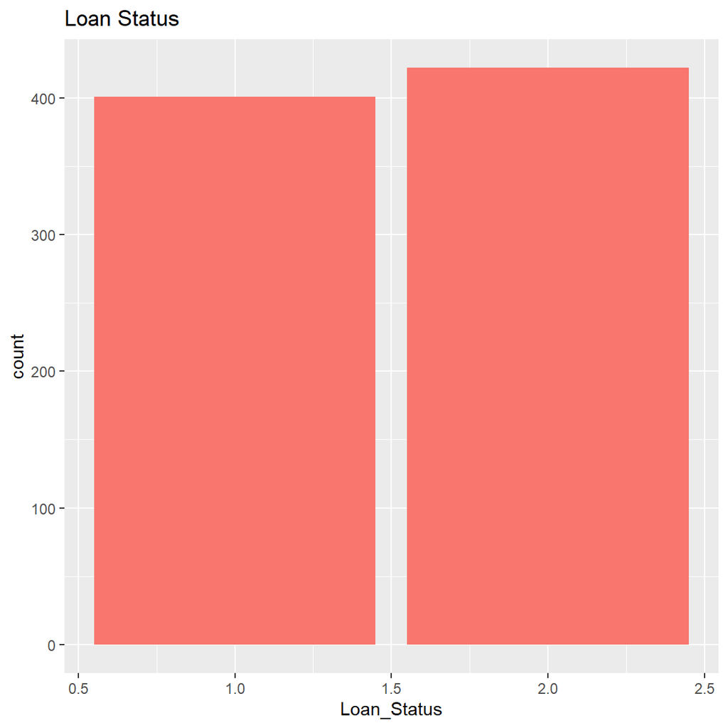

```r
set.seed(123)
dataMWMOTE <- oversample(thisdata, ratio = 0.95, method = "MWMOTE", classAttr = "Loan_Status")
plotImbalance(dataMWMOTE)
```

```r
imbalanceRatio(dataMWMOTE, classAttr = "Loan_Status")
```

```
## [1] 0.950237
```